# Analyzing Individual BGG Users

Phil Henrickson

2022-01-01

# **MCLondon’s** BoardGameGeek Collection

This notebook contains a set of analyses for the selected user’s boardgamegeek collection. The bulk of the analysis is focused on building a user-specific predictive model to predict the games that MCLondon is likely to own. This enables to ask questions like, based on the games the user currently owns, what games are a good fit for their collection? What upcoming games are they likely to purchase?

This analysis is based on data from BoardGameGeek that was last updated on **2021-12-20.**

# 1 Collection Overview

We can look at a basic description of the number of games that the user owns, has rated, has previously owned, etc.

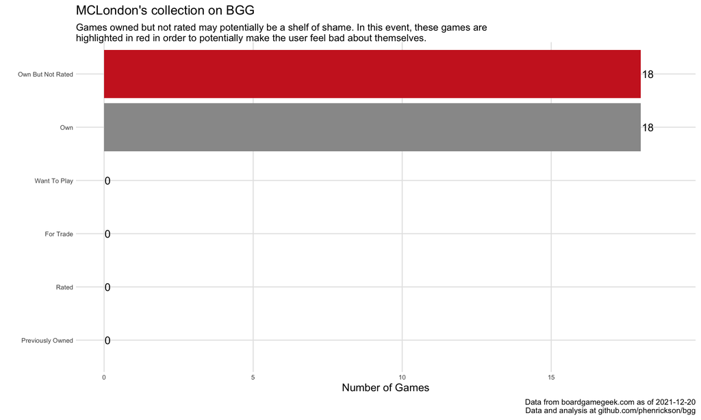

What years has the user owned/rated games from? While we can’t see when a user added or removed a game from their collection, we can look at their collection by the years in which their games were published.

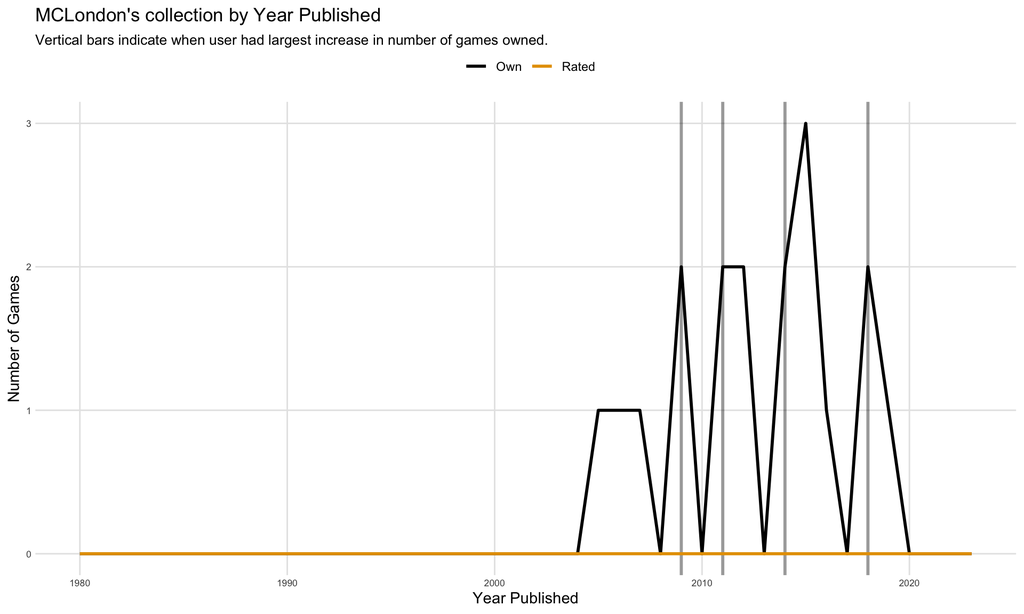

## 1.1 What types of games does MCLondon own?

We can look at the most frequent types of categories, mechanics, designers, and artists that appear in a user’s collection.

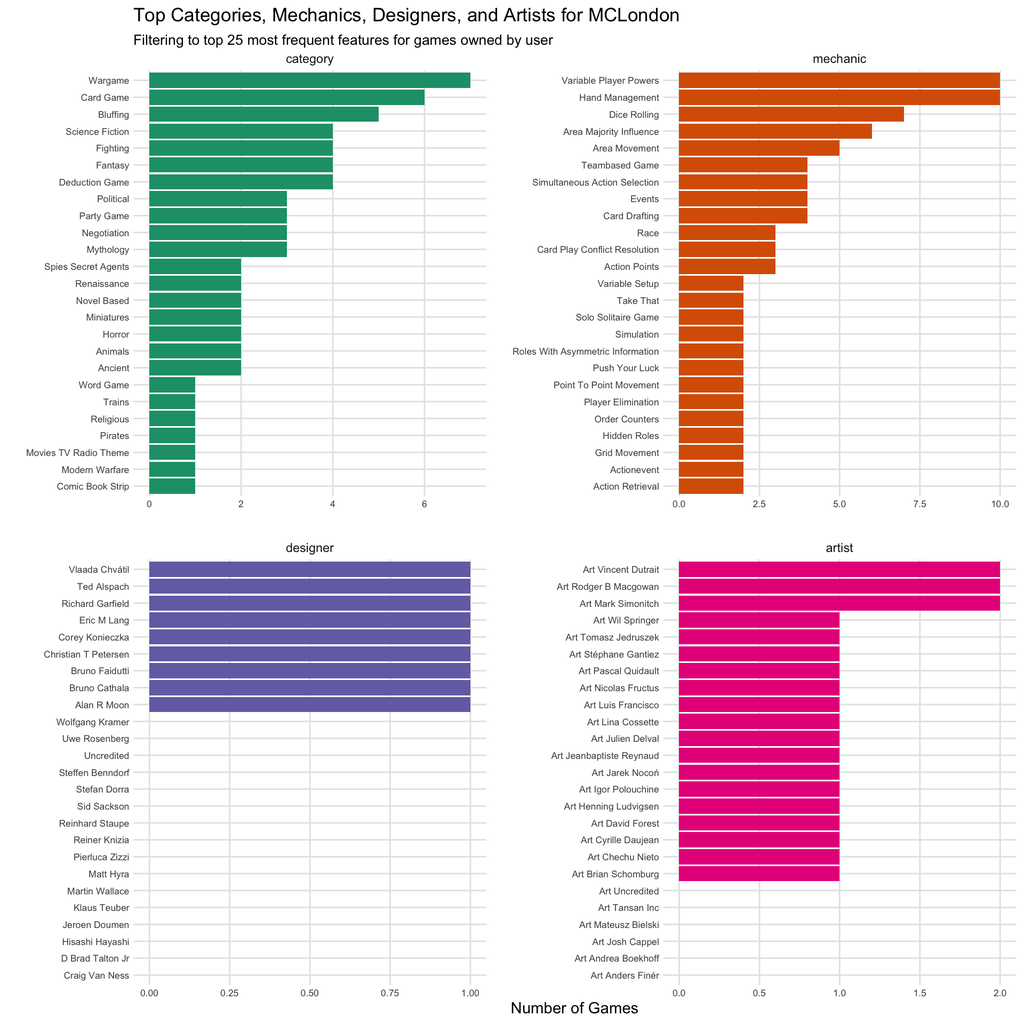

# 2 Modeling **MCLondon’s** Collection

| username | dataset | period | games_owned | games_rated | games_played |
| --- | --- | --- | --- | --- | --- |
| MCLondon | training | published before 2018 | 15 | 0 | 15 |
| MCLondon | test | published 2018 or later | 3 | 0 | 3 |

There are two main (binary) outcomes we will be modeling for the user.

The first, **own** refers to whether the user currently lists a game as owned in their collection. The second, **played** refers to whether the user currently owns, has rated, or previously owned a game. This means the latter will generally have a larger list of games, but may still be a useful category to examine for people who play lots of games without necessarily owning them.

We will train predictive models to learn the probability that the user will own or play individual games based on their features.

## 2.1 Coefficients for MCLondon

We can examine coefficients from the trained modes, which are penalized logistic regressions fit to our two main outcomes. Positive values indicate that a feature increases a user’s probabilility of owning/rating a game, while negative values indicate a feature decreases the probability.

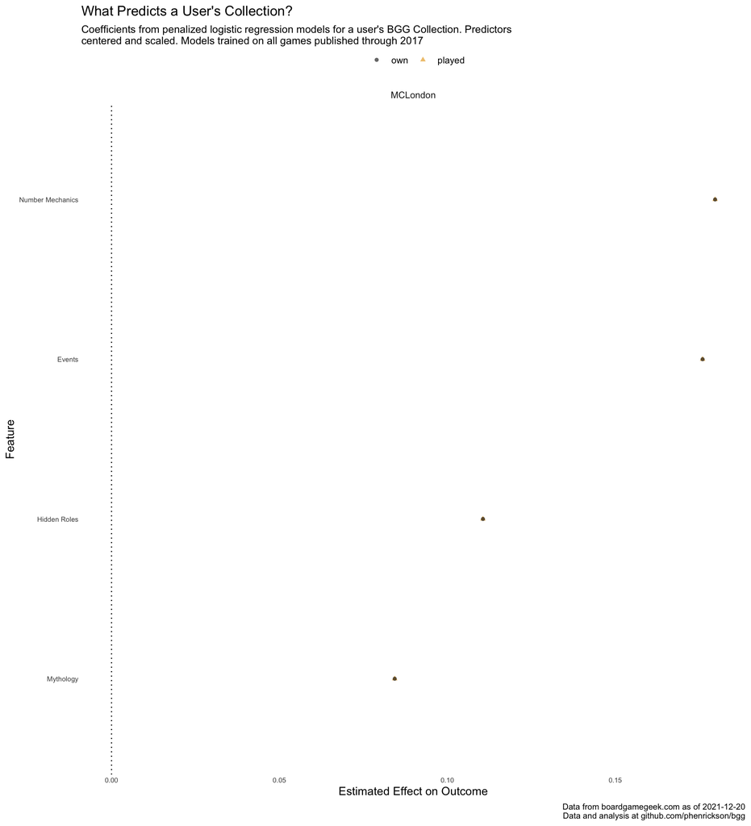

## 2.2 Visualizing Predictors for MCLondon’s Collection

Why did the model identify these features? We can make density plots of the important features for predicting whether the user owned a game. Blue indicates the density for games owned by the user, while grey indicates the density for games not owned by the user.

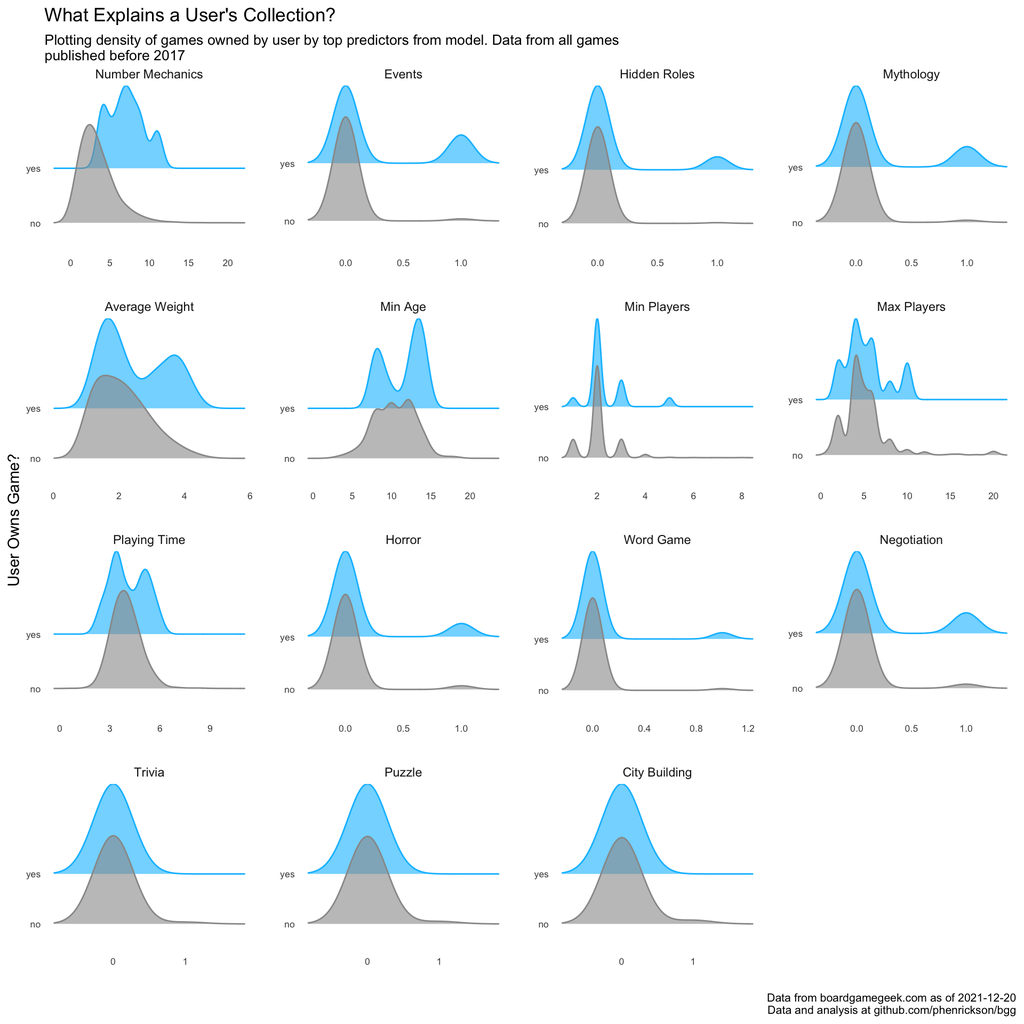

Binary predictors can be difficult to see with this visualization, so we can also directly examine the percentage of games in a user’s collection with a predictor vs the percentage of all games with that predictor.

| username | Feature | % of Games with Feature In_Collection | % of Games with Feature All_Games | Ratio |
| --- | --- | --- | --- | --- |
| MCLondon | Hidden Roles | 13.3% | 0.7% | 19.0 |
| MCLondon | Events | 26.7% | 1.9% | 14.0 |
| MCLondon | Mythology | 20.0% | 2.0% | 9.8 |
| MCLondon | Negotiation | 20.0% | 4.0% | 5.1 |
| MCLondon | Word Game | 6.7% | 1.8% | 3.7 |
| MCLondon | Horror | 13.3% | 3.7% | 3.6 |
| MCLondon | Deduction Game | 20.0% | 6.0% | 3.3 |
| MCLondon | Fighting | 26.7% | 8.9% | 3.0 |
| MCLondon | Trains | 6.7% | 2.3% | 2.9 |
| MCLondon | Miniatures | 13.3% | 4.7% | 2.9 |
| MCLondon | Party Game | 20.0% | 8.7% | 2.3 |
| MCLondon | Trivia | 0.0% | 2.0% | 0.0 |
| MCLondon | Puzzle | 0.0% | 2.8% | 0.0 |
| MCLondon | City Building | 0.0% | 4.1% | 0.0 |
| MCLondon | Racing | 0.0% | 3.1% | 0.0 |
| MCLondon | Action Dexterity | 0.0% | 5.1% | 0.0 |
| MCLondon | Mafia | 0.0% | 0.7% | 0.0 |
| MCLondon | Medieval | 0.0% | 6.2% | 0.0 |
| MCLondon | Prehistoric | 0.0% | 1.0% | 0.0 |
| MCLondon | Realtime | 0.0% | 4.0% | 0.0 |
| MCLondon | Sports | 0.0% | 2.2% | 0.0 |
| MCLondon | Murdermystery | 0.0% | 1.6% | 0.0 |
| MCLondon | Childrens Game | 0.0% | 6.3% | 0.0 |
| MCLondon | Memory Game | 0.0% | 1.9% | 0.0 |
| MCLondon | World War II | 0.0% | 4.2% | 0.0 |

# 3 Assess Model’s Performance on Training Set

Before predicting games in upcoming years, we can examine how well the model did and what games it liked in the training set. In this case, we used resampling techniques (cross validation) to ensure that the model had not seen a game before making its predictions.

## 3.1 Separation Plot

An easy way to examine the performance of classification model is to view a separation plot. We plot the predicted probabilities from the model for every game (from resampling) from lowest to highest. We then overlay a blue line for any game that the user does own. A good classifier is one that is able to *separate* the blue (games owned by the user) from the white (games not owned by the user), with most of the blue occurring at the highest probabilities (right side of the chart).

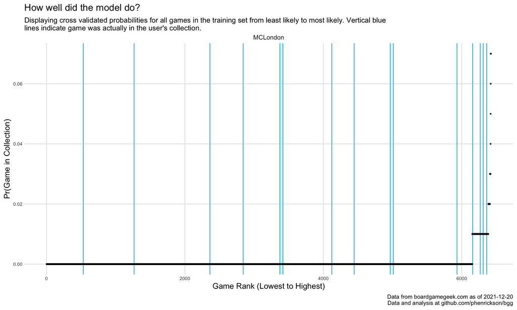

## 3.2 Top Games for **MCLondon** from Training Set

We can display this information in table form, displaying the 100 games with the highest probability of ownership, adding a blue line when the user does own the game.

| username | yearpublished | game_id | name | pred_played | pred_own | actual_played | actual_own |
| --- | --- | --- | --- | --- | --- | --- | --- |
| MCLondon | 2011 | 91312 | Discworld: Ankh-Morpork | 0.07 | 0.07 | 0 | 0 |
| MCLondon | 2017 | 162886 | Spirit Island | 0.07 | 0.07 | 0 | 0 |
| MCLondon | 2014 | 146652 | Legendary Encounters: An Alien Deck Building Game | 0.06 | 0.06 | 0 | 0 |
| MCLondon | 2014 | 156129 | Deception: Murder in Hong Kong | 0.05 | 0.05 | 0 | 0 |
| MCLondon | 2012 | 121921 | Robinson Crusoe: Adventures on the Cursed Island | 0.04 | 0.04 | 0 | 0 |
| MCLondon | 2014 | 156091 | Sons of Anarchy: Men of Mayhem | 0.03 | 0.03 | 0 | 0 |
| MCLondon | 2015 | 162865 | I, Spy | 0.03 | 0.03 | 0 | 0 |
| MCLondon | 1985 | 3149 | Lost Valley of the Dinosaurs | 0.03 | 0.03 | 0 | 0 |
| MCLondon | 2005 | 15987 | Arkham Horror | 0.03 | 0.03 | 0 | 0 |
| MCLondon | 1993 | 1094 | Assassin | 0.03 | 0.03 | 0 | 0 |
| MCLondon | 2008 | 37111 | Battlestar Galactica: The Board Game | 0.03 | 0.03 | 0 | 0 |
| MCLondon | 2013 | 141418 | LEADERS: The Combined Strategy Game | 0.03 | 0.03 | 0 | 0 |
| MCLondon | 2013 | 141517 | A Study in Emerald | 0.03 | 0.03 | 0 | 0 |
| MCLondon | 2015 | 178054 | A Study in Emerald (Second Edition) | 0.03 | 0.03 | 0 | 0 |
| MCLondon | 2010 | 62227 | Labyrinth: The War on Terror, 2001 – ? | 0.02 | 0.02 | 0 | 0 |
| MCLondon | 2004 | 6613 | Downtown: Air War Over Hanoi, 1965-1972 | 0.02 | 0.02 | 0 | 0 |
| MCLondon | 1976 | 3575 | The Plot to Assassinate Hitler | 0.02 | 0.02 | 0 | 0 |
| MCLondon | 1981 | 1032 | B-17: Queen of the Skies | 0.02 | 0.02 | 0 | 0 |
| MCLondon | 2017 | 218530 | Tortuga 1667 | 0.02 | 0.02 | 0 | 0 |
| MCLondon | 2017 | 186751 | Mythic Battles: Pantheon | 0.02 | 0.02 | 0 | 0 |
| MCLondon | 2016 | 192802 | Days of Ire: Budapest 1956 | 0.02 | 0.02 | 0 | 0 |
| MCLondon | 2000 | 478 | Citadels | 0.02 | 0.02 | 0 | 0 |
| MCLondon | 2004 | 11945 | Linq | 0.02 | 0.02 | 0 | 0 |
| MCLondon | 2010 | 82168 | Escape from the Aliens in Outer Space | 0.02 | 0.02 | 0 | 0 |
| MCLondon | 2014 | 153064 | Good Cop Bad Cop | 0.02 | 0.02 | 0 | 0 |
| MCLondon | 2013 | 143741 | BANG! The Dice Game | 0.02 | 0.02 | 0 | 0 |
| MCLondon | 1980 | 1720 | Dragon Pass | 0.02 | 0.02 | 0 | 0 |
| MCLondon | 2002 | 3955 | BANG! | 0.02 | 0.02 | 0 | 0 |
| MCLondon | 2014 | 152241 | Ultimate Werewolf | 0.02 | 0.02 | 0 | 0 |
| MCLondon | 1976 | 3083 | Submarine | 0.02 | 0.02 | 0 | 0 |

[output cut: 70 more lines]

We can also more formally assess how well the model did in resampling by looking at the area under the receiver operating characteristic. A perfect model would receive a score of 1, while a model that cannot predict the outcome will default to a score of 0.5. The extent to which something is a *good* score depends on the setting, but generally anything in the .8 to .9 range is very good while the .7 to .8 range is perfectly acceptable.

| username | outcome_type | .metric | .estimator | .estimate |
| --- | --- | --- | --- | --- |
| MCLondon | own | roc_auc | binary | 0.672 |
| MCLondon | played | roc_auc | binary | 0.672 |

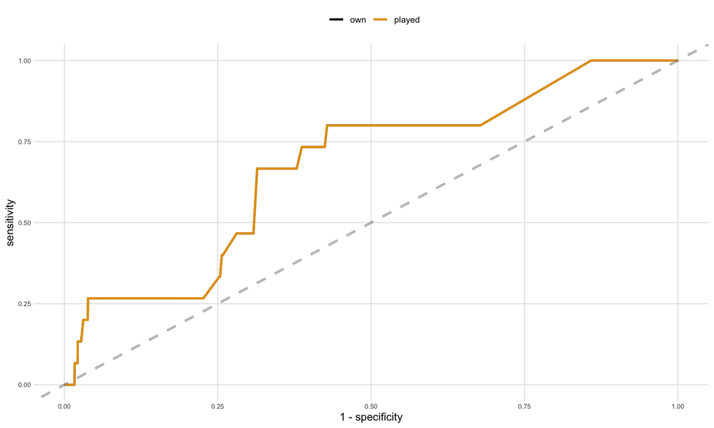

Another way to think about the model performance is to view its lift, or its ability to detect the positive outcomes over that of a null model. High lift indicates the model can much more quickly find all of the positive outcomes (in this case, games owned or played by the user), while a model with no lift is no better than random guessing.

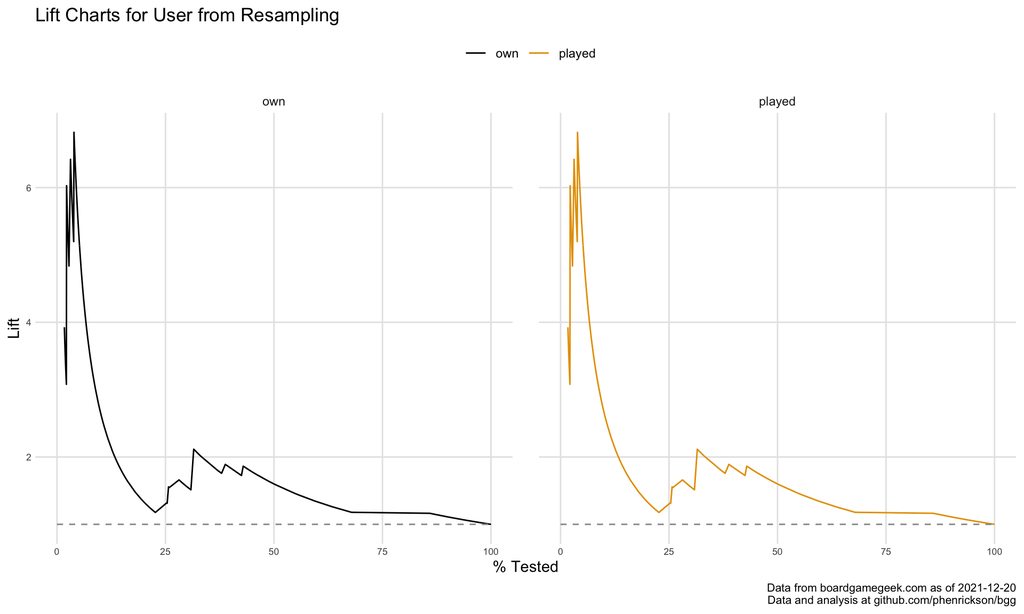

## 3.3 Most and Least Likely Games

What games does the model think MCLondon is **most likely to own** that are **not** in their collection?

| username | yearpublished | game_id | name | pred_own | actual_own |
| --- | --- | --- | --- | --- | --- |
| MCLondon | 2011 | 91312 | Discworld: Ankh-Morpork | 0.07 | 0 |
| MCLondon | 2017 | 162886 | Spirit Island | 0.07 | 0 |
| MCLondon | 2014 | 146652 | Legendary Encounters: An Alien Deck Building Game | 0.06 | 0 |
| MCLondon | 2014 | 156129 | Deception: Murder in Hong Kong | 0.05 | 0 |
| MCLondon | 2012 | 121921 | Robinson Crusoe: Adventures on the Cursed Island | 0.04 | 0 |

What games does the model think MCLondon is **least likely to own** that **are** in their collection?

| username | yearpublished | game_id | name | pred_own | actual_own |
| --- | --- | --- | --- | --- | --- |
| MCLondon | 2015 | 177639 | Raptor | 0 | 1 |
| MCLondon | 2015 | 175155 | Forbidden Stars | 0 | 1 |
| MCLondon | 2014 | 148228 | Splendor | 0 | 1 |
| MCLondon | 2016 | 194655 | Santorini | 0 | 1 |
| MCLondon | 2015 | 178900 | Codenames | 0 | 1 |

## 3.4 Top Games by Year

Top 25 games most likely to be owned by the user in each year, highlighting in blue the games that the user has owned/played.

| rank | 2009 | 2010 | 2011 | 2012 | 2013 | 2014 | 2015 | 2016 | 2017 |
| --- | --- | --- | --- | --- | --- | --- | --- | --- | --- |
| 1 | The Halls of Montezuma | Labyrinth: The War on Terror, 2001 – ? | Discworld: Ankh-Morpork | Robinson Crusoe: Adventures on the Cursed Island | LEADERS: The Combined Strategy Game | Legendary Encounters: An Alien Deck Building Game | I, Spy | Days of Ire: Budapest 1956 | Spirit Island |
| 2 | Soviet Dawn: The Russian Civil War, 1918-1921 | Escape from the Aliens in Outer Space | Dreadfleet | The Resistance: Avalon | A Study in Emerald | Deception: Murder in Hong Kong | A Study in Emerald (Second Edition) | Secret Hitler | Tortuga 1667 |
| 3 | Atlantis | Battles of Westeros | No Peace Without Spain!: The War of the Spanish Succession 1702-1713 | 1989: Dawn of Freedom | BANG! The Dice Game | Sons of Anarchy: Men of Mayhem | One Night Revolution | Thunder & Lightning | Mythic Battles: Pantheon |
| 4 | Chaos in the Old World | Troyes | Omen: A Reign of War | Bloody April, 1917: Air War Over Arras, France | Cruel Necessity: The English Civil Wars 1640-1653 | Good Cop Bad Cop | Haleakala | Fight for Olympus | Konja |
| 5 | Are You the Traitor? | Merchants & Marauders | Pantheon | In Magnificent Style: Pickett's Charge at Gettysburg | The Witches: A Discworld Game | Ultimate Werewolf | Sylvion | Star Trek: The Dice Game | Vikings Gone Wild |
| 6 | Kachina | Earth Reborn | Space Empires: 4X | Divided Republic | Eight-Minute Empire: Legends | [redacted] | Spirits of the Rice Paddy | The Arrival | Fallout |
| 7 | Name 5 | Felinia | 011 | War of the Ring: Second Edition | Story War | Smash Up: Science Fiction Double Feature | Blood Rage | Falling Sky: The Gallic Revolt Against Caesar | Pendragon: The Fall of Roman Britain |
| 8 | Waterloo | Two by Two | Dungeon Fighter | Venture Forth | Impulse | Smash Up: Monster Smash | Burgle Bros. | Meduris: Der Ruf der Götter | Yamataï |
| 9 | The Caucasus Campaign | Genesis | Mansions of Madness | Wiz-War (Eighth Edition) | Munchkin Legends | Sellswords | Kingdom Death: Monster | Valley of the Kings: Last Rites | Dice Forge |
| 10 | Grind | Dominant Species | Band of Brothers: Screaming Eagles | Il Vecchio | Spyrium | The Draugr | Journey: Wrath of Demons | Dokmus | Gloomhaven |
| 11 | Dungeon Twister 2: Prison | Myth: Pantheons | A Few Acres of Snow | Mythic Battles | Forbidden Desert | The Lord of the Ice Garden | Elysium | Bios: Genesis | Outlive |
| 12 | Space Hulk (Third Edition) | Poseidon | Sekigahara: The Unification of Japan | Teomachia | Nations | Deus | Bomarzo | Cry Havoc | The Chameleon |
| 13 | Hellenes: Campaigns of the Peloponnesian War | Nations at War: White Star Rising | Fighting Formations: Grossdeutschland Motorized Infantry Division | Asgard | Dungeon Command: Blood of Gruumsh | Ancient Terrible Things | 504 | Timebomb | Divinity Derby |
| 14 | A Victory Denied: Crisis at Smolensk, July-September, 1941 | Battles of Napoleon: The Eagle and the Lion | No Retreat! The Russian Front | Shadows over Camelot: The Card Game | Band of Brothers: Ghost Panzer | Helios | Through the Ages: A New Story of Civilization | Insider | Vikingar: The Conquest of Worlds |
| 15 | Baltic Gap: Summer 1944 | Washington's War | Nightfighter | One Night Werewolf | BattleLore: Second Edition | Valley of the Kings | Siggil | Star Trek: Ascendancy | Arena: For the Gods! |
| 16 | Battle for Moscow: Operation Typhoon, 1941 | Commands & Colors: Napoleonics | Space Infantry | Atlantis Rising | No Retreat!: The North African Front | Hexemonia | Neanderthal | Evolution: Climate | This War of Mine: The Board Game |
| 17 | Claustrophobia | Hearts and Minds: Vietnam 1965-1975 | FAB: Sicily | Android: Infiltration | Crusade and Revolution: The Spanish Civil War, 1936-1939 | Nations: The Dice Game | One Night Ultimate Werewolf: Daybreak | Kreus | One Night Ultimate Alien |
| 18 | The Pillars of the Earth: Builders Duel | Battle Above the Clouds | Revolver | Kanzume Goddess | Sedition Wars: Battle for Alabaster | Alchemists | One Night Ultimate Vampire | Mansions of Madness: Second Edition | Stworze |
| 19 | Campaign Manager 2008 | Gettysburg | 1955: The War of Espionage | Keyflower | Dungeon Twister: The Card Game | Secret Moon | Wings for the Baron (Second Edition) | Mare Nostrum: Empires | Pixie Queen |
| 20 | Arena: Roma II | The Spanish Civil War 1936-1939 | Test of Fire: Bull Run 1861 | Space Cadets | Invaders | Templar Intrigue | Warehouse 51 | The Manhattan Project: Energy Empire | Unreal Estate |
| 21 | Burger Joint | Warhammer: The Island of Blood | Steam Torpedo: First Contact | Coup | Risk: Plants vs. Zombies | Pay Dirt | Specter Ops | 3 Wishes | Legendary Forests |
| 22 | Martinique | Warhammer: The Game of Fantasy Battles (8th Edition) | Yomi | A Fake Artist Goes to New York | Metallum | Panthalos | Stronghold: 2nd edition | Old School Tactical: Volume 1 – Fighting on the Eastern Front 1941/42 | Journal 29: Interactive Book Game |
| 23 | Batt'l Kha'os | Magestorm | Laser Chess | Snowdonia | France '40 | Neptun | Wing Leader: Victories 1940-1942 | Silent Victory: U.S. Submarines in the Pacific, 1941-45 | Techno Bowl: Arcade Football Unplugged |
| 24 | Pocket Battles: Celts vs. Romans | Heroscape Master Set: Battle for the Underdark | Ascension: Return of the Fallen | Legendary: A Marvel Deck Building Game | Castellan | Star Wars: Imperial Assault | Warhammer Age of Sigmar | Wing Leader: Supremacy 1943-1945 | Commands & Colors Tricorne: The American Revolution |
| 25 | Penny Arcade: The Card Game | Panzer General: Allied Assault | Drako: Dragon & Dwarves | Archipelago | Island Siege | Fallen | The U.S. Civil War | MBT (Second Edition) | Runewars Miniatures Game |

## 3.5 Interactive Predictions from Resampling

Interactive table for predictions from resampling.

|  | username | yearpublished | rank | game_id | name | pred_played | pred_own | actual_played | actual_own |
| --- | --- | --- | --- | --- | --- | --- | --- | --- | --- |
| 1 | MCLondon | 1900 | 224 | 2785 | Game of Goose | 0.01 | 0.01 | 0 | 0 |
| 2 | MCLondon | 1900 | 283 | 5546 | Marbles | 0 | 0 | 0 | 0 |
| 3 | MCLondon | 1900 | 286 | 11901 | Tic-Tac-Toe | 0 | 0 | 0 | 0 |
| 4 | MCLondon | 1900 | 332 | 188 | Go | 0 | 0 | 0 | 0 |
| 5 | MCLondon | 1900 | 435 | 171 | Chess | 0 | 0 | 0 | 0 |
| 6 | MCLondon | 1900 | 445 | 2065 | Shogi | 0 | 0 | 0 | 0 |
| 7 | MCLondon | 1900 | 447 | 2393 | Xiangqi | 0 | 0 | 0 | 0 |
| 8 | MCLondon | 1900 | 641 | 26952 | International Checkers | 0 | 0 | 0 | 0 |
| 9 | MCLondon | 1900 | 668 | 1602 | The Royal Game of Ur | 0 | 0 | 0 | 0 |
| 10 | MCLondon | 1900 | 669 | 2083 | Checkers | 0 | 0 | 0 | 0 |

[output cut: 6410 more lines]

# 4 Validating the Model on 2018

How well did a model trained on a user’s collection through 2017 perform in predicting games for the user from 2018?

| username | outcome_type | yearpublished | .metric | .estimator | .estimate |
| --- | --- | --- | --- | --- | --- |
| MCLondon | own | 2018 | roc_auc | binary | 0.92 |
| MCLondon | played | 2018 | roc_auc | binary | 0.92 |

Table of top 25 games from 2018, highlighting games that the user owns.

| username | yearpublished | game_id | name | pred_own | pred_played | actual_own | actual_played |
| --- | --- | --- | --- | --- | --- | --- | --- |
| MCLondon | 2018 | 119881 | Medioevo Universale | 0.01 | 0.01 | 0 | 0 |
| MCLondon | 2018 | 165186 | Hitler's Reich: WW2 in Europe | 0.01 | 0.01 | 0 | 0 |
| MCLondon | 2018 | 167355 | Nemesis | 0.01 | 0.01 | 0 | 0 |
| MCLondon | 2018 | 205896 | Rising Sun | 0.01 | 0.01 | 0 | 0 |
| MCLondon | 2018 | 218421 | Street Masters | 0.01 | 0.01 | 0 | 0 |
| MCLondon | 2018 | 222219 | Kero | 0.01 | 0.01 | 0 | 0 |
| MCLondon | 2018 | 222509 | Lords of Hellas | 0.01 | 0.01 | 0 | 0 |
| MCLondon | 2018 | 225167 | Human Punishment: Social Deduction 2.0 | 0.01 | 0.01 | 0 | 0 |
| MCLondon | 2018 | 227460 | Hannibal & Hamilcar | 0.01 | 0.01 | 0 | 0 |
| MCLondon | 2018 | 229956 | Fort Sumter: The Secession Crisis, 1860-61 | 0.01 | 0.01 | 0 | 0 |
| MCLondon | 2018 | 230191 | The Island of El Dorado | 0.01 | 0.01 | 0 | 0 |
| MCLondon | 2018 | 245422 | Werewords Deluxe Edition | 0.01 | 0.01 | 0 | 0 |
| MCLondon | 2018 | 248763 | Magic: The Gathering – Heroes of Dominaria Board Game | 0.01 | 0.01 | 0 | 0 |
| MCLondon | 2018 | 256877 | Hail Hydra | 0.01 | 0.01 | 0 | 0 |
| MCLondon | 2018 | 125977 | Cataclysm: A Second World War | 0.00 | 0.00 | 0 | 0 |
| MCLondon | 2018 | 138026 | Critical Mass: Raijin vs Archon | 0.00 | 0.00 | 0 | 0 |
| MCLondon | 2018 | 147241 | Oaxaca: Crafts of a Culture | 0.00 | 0.00 | 0 | 0 |
| MCLondon | 2018 | 154910 | Darklight: Memento Mori | 0.00 | 0.00 | 0 | 0 |
| MCLondon | 2018 | 155122 | 1066, Tears to Many Mothers | 0.00 | 0.00 | 0 | 0 |
| MCLondon | 2018 | 158753 | Clash of Rage | 0.00 | 0.00 | 0 | 0 |
| MCLondon | 2018 | 158815 | At Any Cost: Metz 1870 | 0.00 | 0.00 | 0 | 0 |
| MCLondon | 2018 | 165292 | The Dark Sands: War in North Africa, 1940-42 | 0.00 | 0.00 | 0 | 0 |
| MCLondon | 2018 | 165967 | Great War Commander | 0.00 | 0.00 | 0 | 0 |
| MCLondon | 2018 | 170604 | Renegade | 0.00 | 0.00 | 0 | 0 |
| MCLondon | 2018 | 170624 | Crusaders: Thy Will Be Done | 0.00 | 0.00 | 0 | 0 |

# 5 Predicting Upcoming Games (2018 and On) for **MCLondon**

Examine the top games for the test set.

| username | yearpublished | game_id | name | rank | own | played |
| --- | --- | --- | --- | --- | --- | --- |
| MCLondon | 2018 | 222509 | Lords of Hellas | 1 | 0.01 | 0.01 |
| MCLondon | 2018 | 230191 | The Island of El Dorado | 2 | 0.01 | 0.01 |
| MCLondon | 2018 | 245422 | Werewords Deluxe Edition | 3 | 0.01 | 0.01 |
| MCLondon | 2018 | 225167 | Human Punishment: Social Deduction 2.0 | 4 | 0.01 | 0.01 |
| MCLondon | 2018 | 256877 | Hail Hydra | 5 | 0.01 | 0.01 |
| MCLondon | 2018 | 165186 | Hitler's Reich: WW2 in Europe | 6 | 0.01 | 0.01 |
| MCLondon | 2018 | 248763 | Magic: The Gathering – Heroes of Dominaria Board Game | 7 | 0.01 | 0.01 |
| MCLondon | 2018 | 227460 | Hannibal & Hamilcar | 8 | 0.01 | 0.01 |
| MCLondon | 2018 | 229956 | Fort Sumter: The Secession Crisis, 1860-61 | 9 | 0.01 | 0.01 |
| MCLondon | 2018 | 119881 | Medioevo Universale | 10 | 0.01 | 0.01 |
| MCLondon | 2018 | 205896 | Rising Sun | 11 | 0.01 | 0.01 |
| MCLondon | 2018 | 218421 | Street Masters | 12 | 0.01 | 0.01 |
| MCLondon | 2018 | 222219 | Kero | 13 | 0.01 | 0.01 |
| MCLondon | 2018 | 167355 | Nemesis | 14 | 0.01 | 0.01 |
| MCLondon | 2018 | 204504 | Outlaws: Last Man Standing | 15 | 0.00 | 0.00 |
| MCLondon | 2018 | 244916 | Drop It | 16 | 0.00 | 0.00 |
| MCLondon | 2018 | 245389 | Word Slam Family | 17 | 0.00 | 0.00 |
| MCLondon | 2018 | 248002 | TAGS | 18 | 0.00 | 0.00 |
| MCLondon | 2018 | 255332 | Vault of Dragons | 19 | 0.00 | 0.00 |
| MCLondon | 2018 | 256538 | Home Alone Game | 20 | 0.00 | 0.00 |
| MCLondon | 2018 | 257284 | Timeline: Classic | 21 | 0.00 | 0.00 |
| MCLondon | 2018 | 261262 | Blöde Kuh | 22 | 0.00 | 0.00 |
| MCLondon | 2018 | 186904 | The Champion of the Wild | 23 | 0.00 | 0.00 |
| MCLondon | 2018 | 204575 | Way of the Panda | 24 | 0.00 | 0.00 |
| MCLondon | 2018 | 215341 | Thunderstone Quest | 25 | 0.00 | 0.00 |
| MCLondon | 2019 | 249746 | Nanty Narking | 1 | 0.04 | 0.04 |
| MCLondon | 2019 | 217576 | Hellenica: Story of Greece | 2 | 0.03 | 0.03 |
| MCLondon | 2019 | 276025 | Maracaibo | 3 | 0.02 | 0.02 |
| MCLondon | 2019 | 266507 | Clank!: Legacy – Acquisitions Incorporated | 4 | 0.02 | 0.02 |
| MCLondon | 2019 | 267304 | Western Empires | 5 | 0.01 | 0.01 |
| MCLondon | 2019 | 267652 | Dungeonology: The Expedition | 6 | 0.01 | 0.01 |
| MCLondon | 2019 | 274638 | Unmatched: Robin Hood vs. Bigfoot | 7 | 0.01 | 0.01 |
| MCLondon | 2019 | 299121 | Machina Arcana (Second/Third Edition) | 8 | 0.01 | 0.01 |
| MCLondon | 2019 | 274637 | Unmatched: Battle of Legends, Volume One | 9 | 0.01 | 0.01 |
| MCLondon | 2019 | 219217 | Arena: The Contest | 10 | 0.01 | 0.01 |
| MCLondon | 2019 | 265381 | DANY | 11 | 0.01 | 0.01 |
| MCLondon | 2019 | 254513 | The Grimm Masquerade | 12 | 0.01 | 0.01 |
| MCLondon | 2019 | 265684 | Subtext | 13 | 0.01 | 0.01 |
| MCLondon | 2019 | 287941 | Formosa Tea | 14 | 0.01 | 0.01 |
| MCLondon | 2019 | 264220 | Tainted Grail: The Fall of Avalon | 15 | 0.01 | 0.01 |
| MCLondon | 2019 | 196257 | Castle Itter | 16 | 0.01 | 0.01 |
| MCLondon | 2019 | 249590 | Nevsky: Teutons and Rus in Collision 1240-1242 | 17 | 0.01 | 0.01 |
| MCLondon | 2019 | 210296 | DinoGenics | 18 | 0.01 | 0.01 |
| MCLondon | 2019 | 239472 | Abomination: The Heir of Frankenstein | 19 | 0.01 | 0.01 |
| MCLondon | 2019 | 264052 | Circadians: First Light | 20 | 0.01 | 0.01 |
| MCLondon | 2019 | 254588 | Hearts and Minds: Vietnam 1965-1975 (Third Edition) | 21 | 0.01 | 0.01 |
| MCLondon | 2019 | 253574 | Crusader Kings | 22 | 0.01 | 0.01 |
| MCLondon | 2019 | 265260 | Revolution of 1828 | 23 | 0.00 | 0.00 |
| MCLondon | 2019 | 266938 | Smash Up: World Tour – International Incident | 24 | 0.00 | 0.00 |
| MCLondon | 2019 | 267475 | Stay Cool | 25 | 0.00 | 0.00 |
| MCLondon | 2020 | 292333 | Cowboys II: Cowboys & Indians Edition | 1 | 0.08 | 0.08 |
| MCLondon | 2020 | 325635 | Unmatched: Little Red Riding Hood vs. Beowulf | 2 | 0.01 | 0.01 |
| MCLondon | 2020 | 184267 | On Mars | 3 | 0.01 | 0.01 |
| MCLondon | 2020 | 256317 | Guild Master | 4 | 0.01 | 0.01 |
| MCLondon | 2020 | 291457 | Gloomhaven: Jaws of the Lion | 5 | 0.01 | 0.01 |
| MCLondon | 2020 | 269847 | Dracula's Feast: New Blood | 6 | 0.01 | 0.01 |
| MCLondon | 2020 | 298261 | Mekhane | 7 | 0.01 | 0.01 |
| MCLondon | 2020 | 284981 | Zona Alfa: Salvage and Survival in the Exclusion Zone | 8 | 0.01 | 0.01 |
| MCLondon | 2020 | 291874 | Dwergar | 9 | 0.01 | 0.01 |
| MCLondon | 2020 | 292684 | Mindburners | 10 | 0.01 | 0.01 |
| MCLondon | 2020 | 326408 | Una Questione di Voto | 11 | 0.01 | 0.01 |
| MCLondon | 2020 | 240901 | A Time for Trumpets: The Battle of the Bulge, December 1944 | 12 | 0.01 | 0.01 |
| MCLondon | 2020 | 282765 | Mint Cooperative | 13 | 0.01 | 0.01 |
| MCLondon | 2020 | 299946 | Eiyo | 14 | 0.01 | 0.01 |
| MCLondon | 2020 | 263421 | Enigma: Beyond Code | 15 | 0.01 | 0.01 |
| MCLondon | 2020 | 307997 | Insider Black | 16 | 0.01 | 0.01 |
| MCLondon | 2020 | 323784 | Ghost Letters | 17 | 0.01 | 0.01 |
| MCLondon | 2020 | 174959 | The First Jihad: The Rise of Islam 632-750 | 18 | 0.01 | 0.01 |
| MCLondon | 2020 | 255902 | Napoleon 1807 | 19 | 0.01 | 0.01 |
| MCLondon | 2020 | 276386 | Caesar: Rome vs. Gaul | 20 | 0.01 | 0.01 |
| MCLondon | 2020 | 279975 | An Attrition of Souls | 21 | 0.01 | 0.01 |
| MCLondon | 2020 | 310448 | Zombie Teenz Evolution | 22 | 0.01 | 0.01 |
| MCLondon | 2020 | 313349 | Indus 2500 BCE | 23 | 0.01 | 0.01 |
| MCLondon | 2020 | 317985 | Beyond the Sun | 24 | 0.01 | 0.01 |
| MCLondon | 2020 | 332782 | Cantaloop: Prequel | 25 | 0.01 | 0.01 |

## 5.1 Interactive Table for Upcoming Games 2018 and On

|  | username | yearpublished | game_id | name | rank | own | played |
| --- | --- | --- | --- | --- | --- | --- | --- |
| 1 | MCLondon | 2020 | 292333 | Cowboys II: Cowboys &amp; Indians Edition | 1 | 0.08 | 0.08 |
| 2 | MCLondon | 2019 | 249746 | Nanty Narking | 2 | 0.04 | 0.04 |
| 3 | MCLondon | 2019 | 217576 | Hellenica: Story of Greece | 3 | 0.03 | 0.03 |
| 4 | MCLondon | 2019 | 276025 | Maracaibo | 4 | 0.02 | 0.02 |
| 5 | MCLondon | 2019 | 266507 | Clank!: Legacy – Acquisitions Incorporated | 5 | 0.02 | 0.02 |
| 6 | MCLondon | 2018 | 222509 | Lords of Hellas | 6 | 0.01 | 0.01 |
| 7 | MCLondon | 2018 | 230191 | The Island of El Dorado | 7 | 0.01 | 0.01 |
| 8 | MCLondon | 2019 | 267304 | Western Empires | 8 | 0.01 | 0.01 |
| 9 | MCLondon | 2019 | 267652 | Dungeonology: The Expedition | 9 | 0.01 | 0.01 |
| 10 | MCLondon | 2019 | 274638 | Unmatched: Robin Hood vs. Bigfoot | 10 | 0.01 | 0.01 |

[output cut: 1923 more lines]